# Negative Binomial Regression

## Negative Binomial Regression

- We can model count outcomes using negative binomial regression,

$$\ln\left( y \right) = \beta_0 + \beta_1 x_1 + ... + \beta_k x_k$$

- This is similar to Poisson regression.
  - For interpretations, we are not interested in the natural log of the count.
  - We will again interpret in terms of incident rate ratios (IRR).

## Negative Binomial Regression

- Negative binomial regression is used specifically for *count response variables*.
  - Examples:
    - Number of votes received
    - Number of attempts before success
- How is this different than Poisson regression?

## Negative Binomial Distribution

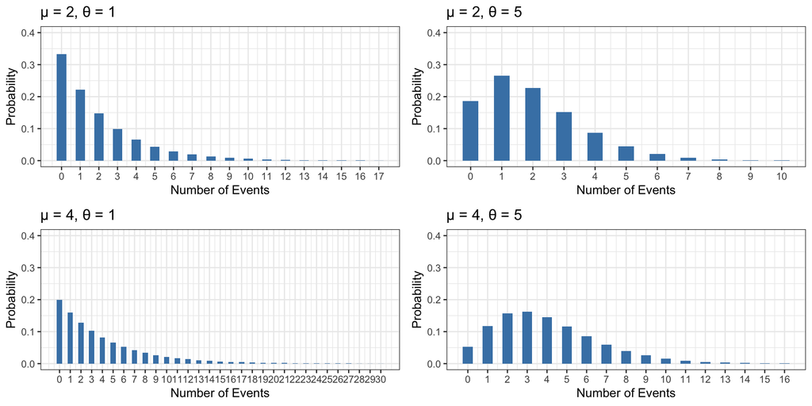

## Poisson or Negative Binomial?

- How do I determine which to use?
- Easy check: mean and variance.
  - Literally, `mean()` and `var()`.

```r
mean(dataset_name$count_variable)
var(dataset_name$count_variable)
```

```r
hist(dataset_name$count_variable)
```

## Poisson or Negative Binomial?

- Wait – why do we care?
- When data is overdispersed, we know that the standard error for $\beta_i$ is underestimated in Poisson regression.
  - The SE is in the denominator of the test statistic. Smaller value $\to$ higher test statistic.
  - Larger test statistic $\to$ smaller $p$-value.
  - Smaller $p$-value $\to$ easier to reject the null hypothesis.
  - Rejecting when we should not is a Type I error.
- When we apply the negative binomial instead, the overdispersion parameter remedies this issue.

## Lecture Example Set Up

- Pluto spends his days at Mickey’s park chasing squirrels and interacting with guests. Disney researchers are interested in understanding what factors influence the number of squirrels Pluto chases per hour.
- For 300 observation periods, researchers recorded:
  - *squirrels_chased*: Number of squirrels chased during the observation period
  - *temperature*: Temperature (°F)
  - *crowd*: Park crowd level (guests per 100 people)
  - *mickey_present*: Whether Mickey is present (Yes/No)
  - *time_of_day*: Time of day (Morning, Afternoon, Evening)

## Lecture Example Set Up

- Pulling in the data,

```r
pluto <- read_csv("https://raw.githubusercontent.com/samanthaseals/SDSII/refs/heads/main/files/data/lectures/W6_pluto.csv")
pluto %>% head()
```

| squirrels_chased | temperature | crowd | mickey_present | time_of_day |
| --- | --- | --- | --- | --- |
| 66 | 71 | 42.6 | Yes | Afternoon |
| 40 | 71 | 58.2 | No | Afternoon |
| 37 | 84 | 62.1 | No | Morning |
| 54 | 88 | 46.1 | Yes | Morning |
| 48 | 76 | 56.5 | No | Afternoon |
| 57 | 76 | 69.3 | Yes | Evening |

## Example 1: Poisson Regression

- Recall the first model from last lecture: the number of squirrels chased as a function of temperature, crowd, and their interaction.

```r
m1_poi <- glm(squirrels_chased ~ temperature + crowd + temperature:crowd,
                 data = pluto,
                 family = poisson(link = "log"))
m1_poi %>% tidy()
```

| term | estimate | std.error | statistic | p.value |
| --- | --- | --- | --- | --- |
| (Intercept) | 0.1857624458 | 3.277795e-01 | 0.5667299 | 5.708977e-01 |
| temperature | 0.0363002481 | 4.313848e-03 | 8.4148190 | 3.935022e-17 |
| crowd | 0.0393306623 | 6.113214e-03 | 6.4337124 | 1.245243e-10 |
| temperature:crowd | -0.0003112087 | 8.055095e-05 | -3.8635017 | 1.117731e-04 |

## Example 1: Poisson Regression

- Let’s now examine the outcome,

```r
mean(pluto$squirrels_chased)
```

```
[1] 41.36333
```

```r
var(pluto$squirrels_chased)
```

```
[1] 345.6903
```

```r
hist(pluto$squirrels_chased)
```

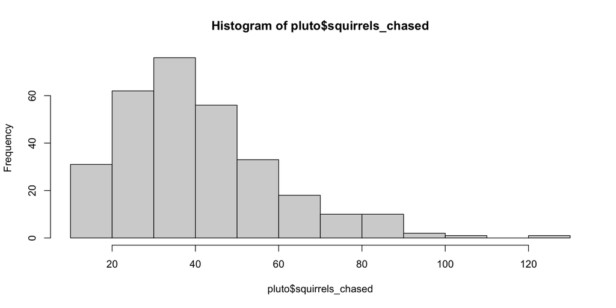

- There is definitely overdispersion in this dataset.

## Negative Binomial Regression (R)

- To perform negative binomial regression, we need the `glm.nb()` function from the `MASS` package.
  - `MASS` is another package I will not load in, personally. I call the function directly from the package,

```r
model <- MASS::glm.nb(y ~ x_1 + x_2 + ... + x_k,
                      data = dataset_name)
```

- Again, we can request the incident rate ratios directly out of `tidy()`,

```r
model %>% tidy(conf.int = TRUE, exponentiate = TRUE)
```

- Then, everything else we have learned follows as normal.

## Example 1: Negative Binomial Regression

- Modeling using negative binomial instead,

```r
m1_nb <- MASS::glm.nb(squirrels_chased ~ temperature + crowd + temperature:crowd,
                      data = pluto)
m1_nb %>% tidy()
```

| term | estimate | std.error | statistic | p.value |
| --- | --- | --- | --- | --- |
| (Intercept) | 0.2049441484 | 0.6472187867 | 0.3166536 | 7.515065e-01 |
| temperature | 0.0358999533 | 0.0086521525 | 4.1492511 | 3.335648e-05 |
| crowd | 0.0387828971 | 0.0125807573 | 3.0827156 | 2.051211e-03 |
| temperature:crowd | -0.0003010588 | 0.0001681197 | -1.7907414 | 7.333480e-02 |

## Example 1: Comparison

- Poisson:

| term | estimate | std.error | statistic | p.value |
| --- | --- | --- | --- | --- |
| (Intercept) | 0.1857624458 | 3.277795e-01 | 0.5667299 | 5.708977e-01 |
| temperature | 0.0363002481 | 4.313848e-03 | 8.4148190 | 3.935022e-17 |
| crowd | 0.0393306623 | 6.113214e-03 | 6.4337124 | 1.245243e-10 |
| temperature:crowd | -0.0003112087 | 8.055095e-05 | -3.8635017 | 1.117731e-04 |

- Negative Binomial:

| term | estimate | std.error | statistic | p.value |
| --- | --- | --- | --- | --- |
| (Intercept) | 0.2049441484 | 0.6472187867 | 0.3166536 | 7.515065e-01 |
| temperature | 0.0358999533 | 0.0086521525 | 4.1492511 | 3.335648e-05 |
| crowd | 0.0387828971 | 0.0125807573 | 3.0827156 | 2.051211e-03 |
| temperature:crowd | -0.0003010588 | 0.0001681197 | -1.7907414 | 7.333480e-02 |

## Example 1: Comparison

- Note that the coefficients are not very different…

```r
summary(m1_poi)$coefficients[, 1]
```

```
      (Intercept)       temperature             crowd temperature:crowd
     0.1857624458      0.0363002481      0.0393306623     -0.0003112087
```

```r
summary(m1_nb)$coefficients[, 1]
```

```
      (Intercept)       temperature             crowd temperature:crowd
     0.2049441484      0.0358999533      0.0387828971     -0.0003010588
```

## Example 1: Comparison

- while the standard errors are different…

```r
summary(m1_poi)$coefficients[, 2]
```

```
      (Intercept)       temperature             crowd temperature:crowd
     3.277795e-01      4.313848e-03      6.113214e-03      8.055095e-05
```

```r
summary(m1_nb)$coefficients[, 2]
```

```
      (Intercept)       temperature             crowd temperature:crowd
     0.6472187867      0.0086521525      0.0125807573      0.0001681197
```

## Example 1: Comparison

- … and the *p*-values, too.

```r
summary(m1_poi)$coefficients[, 4]
```

```
      (Intercept)       temperature             crowd temperature:crowd
     5.708977e-01      3.935022e-17      1.245243e-10      1.117731e-04
```

```r
summary(m1_nb)$coefficients[, 4]
```

```
      (Intercept)       temperature             crowd temperature:crowd
     7.515065e-01      3.335648e-05      2.051211e-03      7.333480e-02
```

- Let’s pay particularly close attention to the interaction term…

## Statistical Inference

- Our approach to determining significance remains the same.
  - For continuous and binary predictors, we can use the Wald test ($z$-test from `tidy()`).
  - For omnibus tests, we can use the likelihood ratio test (LRT).
    - Significance of regression line (full/reduced LRT).
    - Significance of categorical predictors with $c \ge 3$ levels (`car::Anova(type = 3)` or full/reduced LRT).
    - Interaction terms with categorical predictors with $c \ge 3$ levels (`car::Anova(type = 3)` or full/reduced LRT).

## Example 1: Significant Regression Line

- Let’s determine if this is a significant regression line.

```r
m1_full <- MASS::glm.nb(squirrels_chased ~ temperature + crowd + temperature:crowd, data = pluto)
m1_reduced <- MASS::glm.nb(squirrels_chased ~ 1, data = pluto)
anova(m1_reduced, m1_full, test = "Chisq")
```

| Model | theta | Resid. df | 2 x log-lik. | Test | df | LR stat. | Pr(Chi) |
| --- | --- | --- | --- | --- | --- | --- | --- |
| 1 | 5.975216 | 299 | -2552.426 |  | NA | NA | NA |
| temperature + crowd + temperature:crowd | 12.273593 | 296 | -2369.825 | 1 vs 2 | 3 | 182.6011 | 0 |

- Yes, this is a significant regression line ($p < 0.001$).

## Example 1: Testing the Interaction

- Let’s now determine if the interaction is significant,

```r
m1_nb %>% car::Anova(type = 3)
```

|  | LR Chisq | Df | Pr(>Chisq) |
| --- | --- | --- | --- |
| temperature | 17.130567 | 1 | 3.489615e-05 |
| crowd | 9.406148 | 1 | 2.162590e-03 |
| temperature:crowd | 3.165242 | 1 | 7.522130e-02 |

- No! The interaction between temperature and crowd is *not* significant ($p = 0.075$).

## Example 1: Removing the Interaction

- Rerunning our model without the interaction,

```r
m1_final <- MASS::glm.nb(squirrels_chased ~ temperature + crowd, data = pluto)
m1_final %>% tidy()
```

| term | estimate | std.error | statistic | p.value |
| --- | --- | --- | --- | --- |
| (Intercept) | 1.31603221 | 0.176255638 | 7.466611 | 8.228685e-14 |
| temperature | 0.02095120 | 0.002184650 | 9.590189 | 8.792357e-22 |
| crowd | 0.01640121 | 0.001344391 | 12.199733 | 3.118451e-34 |

$$\ln\left( y \right) = 1.32 + 0.02 \text{ temp} + 0.02 \text{ crowd}$$

## Interpreting the Model

- Recall the negative binomial regression model,

$$\ln\left( y \right) = \beta_0 + \beta_1 x_1 + ... + \beta_k x_k$$

## Incident Rate Ratios (R)

- Like in Poisson regression, we can request the incident rate ratios directly out of `tidy()`,

```r
model %>% tidy(conf.int = TRUE, exponentiate = TRUE)
```

## Example 1: Interpreting the Model

- Finding our incident rate ratios,

```r
m1_final %>% tidy(conf.int = TRUE, exponentiate = TRUE)
```

| term | estimate | std.error | statistic | p.value | conf.low | conf.high |
| --- | --- | --- | --- | --- | --- | --- |
| (Intercept) | 3.728598 | 0.176255638 | 7.466611 | 8.228685e-14 | 2.625493 | 5.291522 |
| temperature | 1.021172 | 0.002184650 | 9.590189 | 8.792357e-22 | 1.016790 | 1.025589 |
| crowd | 1.016536 | 0.001344391 | 12.199733 | 3.118451e-34 | 1.013845 | 1.019246 |

- In table form,

| Predictor | IRR (95% CI for IRR) | *p*-value |
| --- | --- | --- |
| Temperature | 1.021 (1.017, 1.026) | <0.001 |
| Crowd | 1.017 (1.014, 1.019) | < 0.001 |

## Example 1: Interpreting the Model

- Let’s interpret the incident rate ratios.

| Predictor | IRR (95% CI for IRR) | *p*-value |
| --- | --- | --- |
| Temperature | 1.021 (1.017, 1.026) | <0.001 |
| Crowd | 1.017 (1.014, 1.019) | < 0.001 |

- For every 1°F increase in temperature, the expected number of squirrels chased increases by a factor of 1.021, holding crowd constant. This is a 2.1% increase.
- For every 100 additional guests in the park, the expected number of squirrels chased increases by a factor of 1.017, holding temperature constant. This is a 1.7% increase.

## Wrap Up

- In this lecture, we have introduced negative binomial regression.
  - Negative binomial regression is appropriate for overdispersed count outcomes.
- We again saw the log link function.
  - We interpret coefficients as multiplicative effects on the *count* of the outcome.
  - These are called the incident rate ratios (IRR).
- In the next lecture, we will review visualization of Poisson and negative binomial models.
- Next week, we will bring all topics together and review choosing the appropriate regression model for your data.